# National Nail Technology Written Practical Examination CIB

Effective: January 01, 2021

[figure not shown]

## CANDIDATE INFORMATION BULLETIN (CIB)

**EXAMINATION CONTENT AND IMPORTANT INSTRUCTIONS**

*Please visit your official examination provider website OR www.nictesting.org for the most current bulletin prior to testing.*

The National Nail Technology Written Practical Examination is a licensure examination for Nail Technology, developed by the National-Interstate Council of State Boards of Cosmetology (NIC).

This bulletin contains IMPORTANT INFORMATION regarding National Nail Technology Written Practical Examination content and administration for core services and additional sections and references.

The time allowed for this examination is 120 minutes.

*PLEASE REVIEW ALL INFORMATION CAREFULLY.*

For each NIC National Written Practical Examination, there are multiple parts to every Candidate Information Bulletin (CIB):

- **Important Instructions and Examination Content Domain Sections** – This provides information and guidelines related to administration of the Written Practical examination and information about the scope of content covered in the Written Practical examination.
- **References** – This provides a list of references used to develop and support the content covered in NIC examinations. References will be the same across exam types for each exam.

*BE CERTAIN TO REVIEW ALL PARTS OF THIS NIC EXAMINATION CIB CAREFULLY!*

## IMPORTANT INSTRUCTIONS

### General

- Do not leave the examination area without permission. Permission must be obtained to leave the examination area for any reason, including restroom usage or at the completion of the examination. *Picture ID is required for re-entry into the examination.*
- All examinations are administered in a testing environment.

### Standardized Administration

Due to standardization of the NIC National Examinations, proctors and examiners are required to adhere to the following standards:

- With the exception of verbal instructions, proctors and examination administration personnel are NOT allowed to speak with candidates.
- If a candidate experiences an emergency situation, they may notify the proctor by raising their hand.

#### Prohibited Items

- The following provides examples of materials and actions that are prohibited in the examination room during the examination administration:
  - Possession of cellular phones, watches (of any kind), pagers, tablets, computers, projectors, cameras, or any other electronic or recording devices, printed materials, or handwritten notes.
  - Purses, bags, coats, hats, and any other personal items not directly needed to complete the examination, are not allowed.
- Communicating to other candidates or any examiner.
- Exhibiting disruptive behavior. The above referenced items or actions are not an exhaustive list.

Failure to comply with any of these conditions or exhibiting ANY behavior that suggests an effort to cheat will result in immediate dismissal from the examination and the candidates’ actions reported to the proper authorities.

## NAIL TECHNOLOGY WRITTEN PRACTICAL EXAMINATION CONTENT OUTLINE

### Domain Details

The following outlines the scope of content covered by the NIC National Nail Technology Written Practical Examination. The percentages represent the percentage of items from each domain. The examination contains 60 items, of which 50 items are weighted and contribute to the candidate’s final score.

1. Scientific Concepts (40%)
   1. Infection Control and Safety Practices
      1. Recognize and utilize infection control principles
         1. Process of infection control (e.g., dispensing products, disposal of materials)
      2. Differentiate between single- and multi-use tools
      3. Recognize when cross-contamination occurs
      4. Apply blood exposure procedures
      5. Identify adverse reactions to products or services
      6. Identify ways to prevent work injuries (e.g., ventilation, ergonomics)
   2. Anatomy and Physiology
      1. Identify functions, parts, and structure of the:
         1. nails
         2. skin
      2. Recognize disorders and diseases of the:
         1. nails
         2. skin
      3. Recognize signs and symptoms of disorders, diseases, and conditions of the:
         1. nails
         2. skin
2. Nail Technology Procedures (60%)
   1. Nail Technology Procedures - Client Consultation and Documentation
      1. Identify elements of a client consultation and documentation
      2. Evaluate condition of client’s nails and skin
      3. Recognize conditions that would prohibit service (contraindications)
      4. Determine services or products
   2. Nail Technology Procedures - Nail Service Tools
      1. Identify purpose and function of:
         1. Nail equipment (e.g., electric file, pedicure basin)
         2. Nail implements (e.g., nail clippers, cuticle pusher)
         3. Nail supplies and materials (e.g., cotton, buffer)
         4. Nail products (e.g., polish, lotion)
      2. Follow practices for safe use of tools
   3. Nail Technology Procedures - Nail Service Preparation
   4. Nail Technology Procedures - Manicure and Pedicure Services
      1. Perform procedures for basic manicure and or pedicure service
      2. Recognize purpose and procedure for add-on services
         1. Paraffin
         2. Masks and essential oils
         3. Gel polish
         4. Thermal (e.g., stone, towel)
   5. Nail Technology Procedures - Perform Application/Maintenance and Removal for Nail Enhancement Services
      1. Nail tip
      2. Acrylics
      3. Light-cured gels
      4. Powder dip
   6. Nail Technology Procedures - Perform Post-Service Procedures

## NATIONAL NAIL TECHNOLOGY WRITTEN PRACTICAL EXAMINATION SAMPLE QUESTIONS

1. During a gel polish manicure, the client says they are having an allergic reaction, although they had not disclosed any allergies on the client consultation form. What should the practitioner do?

   A. Discard the product

   B. Diagnose the cause

   C. Discontinue use of the product

   D. Cleanse the nails with alcohol

2. What is the FIRST step in performing a manicure?

   A. Shape the nails

   B. Soften the cuticles

   C. Clean under free edge

   D. Remove old polish

3. A client appears with a yellow-green spot under an artificial nail. What is the cause of this problem?

   A. Tinea

   B. Corrugations

   C. Carcinogen

   D. Bacteria

Answer Key

| Item | Key |
| --- | --- |
| 1 | C |
| 2 | D |
| 3 | D |
| 4 | A, C |
| 5 | C |

4. Please select all images of multi-use items.

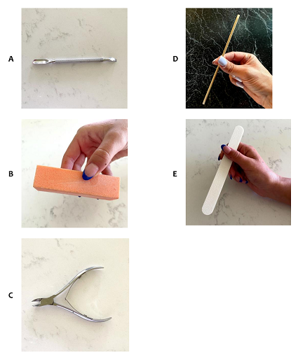

5. Select the lunula in the image provided.

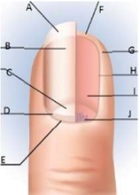

## NATIONAL-INTERSTATE COUNCIL OF STATE BOARDS OF COSMETOLOGY (NIC) REFERENCES

This list provides the references used to develop and support the content covered in the NIC National Nail Technology examinations. References will be the same across exam types for each exam. Candidates are responsible for using these most updated versions of references, as these editions were used to reference test material.

Standard

*Milady Standard Nail Technology 8th Edition + Foundations*

Copyrighted 2020

2020, 8th Edition

ISBN: 9780357446867

Contact: Info@Milady.com www.Milady.com

Copyrighted 2007

CLIC International 2014 Pottsville, PA 17901

*Pivot Point Fundamentals: Nails, (101N - 107N); ©2022 Pivot Point International, Inc.*

Copyrighted 2022

1st Edition, 1st Printing, December 2022

ISBN 978-1-957642-06-2

Pivot Point International, Inc. https://www.pivot-point.com/shop/

Contact: info@pivot-point.com; 847-886-0500, Ext. 7399

*Tammy Taylor Guide to Manicuring and Advanced Nail Technology – Edition III*

Copyrighted 2022

2022, Edition III

ISBN: 978-0-578-25977-2 (Instructor) ISBN: 978-0-578-25978-9 (Student)

Tammy Taylor Nails, Inc. Established 1983 www.tammytaylornails.com

Contact: Education@tammytaylornails.com ; 800-938-2669 Ext. 323

*Today’s Class: Nail Technician*

Copyrighted 2016

2016 Edition

Melior, Inc. https://www.todaysclass.com/index.html

877-224-0435

Supplemental

*Nails – Exhibits of Art*

Copyrighted 2007

2007, 1st Edition

CLIC International 2014

*Salon Fundamentals Nails*

Copyrighted 2013

2013, 1st Edition, 10th printing, June 2013

Pivot Point International, Inc. www.pivot-point.com

Contact: info@pivot-point.com; 847-886-0500, Ext. 7399

*Salon Fundamentals Nails*

Copyrighted 2011

2011, 1st Edition, 7th Printing, October 2011

Pivot Point International, Inc. www.pivot-point.com

Contact: info@pivot-point.com; 847-886-0500, Ext. 7399

Copyright 2021 National-Interstate Council of State Boards of Cosmetology, Inc.